# LCSA_diary

Colby Lee Woodson

12/15/2022

# What is an “LCSA,” why does it matter and how was it made? A combined statistical area is two adjacent metropolitan or micropolitan statistical areas that have an employment interchange measure (EIM) of at least 15. The EIM is the sum of the percentage of workers living in the smaller entity who work in the larger entity and percentage of workers living in the larger entity who work in the smaller entity. This research coins the phrase ‘large combined statistical area’ or LCSA, defined as only those CSAs that contain a metropolitan area. The LSCA is used here as a way to narrow the researcher’s scale to an area that contains a population that is engaged in dynamic inter-county activity, such as concievably relocating to be closer to work or to buy a home for a new family in an adjacent county or nearby town. It is thought that this is an insightful way to learn more about housing costs over the 2010s. However, as the boundaries of a CSA ‘float’ every three to five years, customized LCSAs that contain all the counties that were ever part of an LCSA from 2010 through 2019 were made and statistics derived from county estimates were calculated.

## PACKAGES AND METADATA

```r
####Run on macOS Monterey version 12.5.1
####R version 4.0.3 (2020-10-10); nickname 'Bunny-Wunnies Freak Out'
library(sf)         #1.0-6
library(dplyr)      #1.0.2
library(psych)      #2.2.9
library(tidyr)      #1.1.2
library(tigris)     #1.0
library(ggplot2)    #3.3.2
library(tidyverse)  #1.3.0
library(tidycensus) #1.3.1
options(tigris_use_cache = TRUE)
```

## IMPORTING LCSA COUNTIES GEOIDS AND COST VARIABLES

```r
customized <- read_csv("LCSA_cut.csv")

cut <- customized$GEOID
```

## HOUSING COSTS OVER INCOME

```r
costs <- customized %>%
  pivot_wider(., id_cols = c("year", "GEOID", "NAME", "NAMELSAD"),
              names_from = variable, values_from = c("estimate", "moe")) %>%
  select(year, GEOID, NAME, NAMELSAD,
         RentCost = estimate_B25071_001,             RentCostMOE = moe_B25071_001,
         MortgagorCost = estimate_B25092_002,        MortgagorCostMOE = moe_B25092_002,
         OwnerCost = estimate_B25092_003,            OwnerCostMOE = moe_B25092_003,
         MedianMortAndOwnCost = estimate_B25092_001, MedianMortAndOwnMOE = moe_B25092_001,
         Renters = estimate_B25003_003,              RentersMOE = moe_B25003_003,
         Mortgagors = estimate_B25081_002,           MortgagorsMOE = moe_B25081_002,
         Owners = estimate_B25081_008,               OwnersMOE = moe_B25081_008,
         MortAndOwn = estimate_B25003_002,           MortAndOwnMOE = moe_B25003_002,
         OccupiedTotal = estimate_B25003_001,        OccupiedTotalMOE = moe_B25003_001,
         MedianHousingCost = estimate_B25105_001,    MedianHousingCostMOE = moe_B25105_001) %>%
  filter(!is.na(NAMELSAD))

costs2 <- costs %>% select(year, GEOID, NAME, NAMELSAD, RentCost, MortgagorCost, OwnerCost, MedianMortAndOwnCost,
                           Renters, Mortgagors, Owners, MortAndOwn, OccupiedTotal, MedianHousingCost)

####RE-CODING MISSING MOE AS 0

index <- is.na(costs2)
costs2[index] <- 0

costs3 <- costs2 %>%
  select(year, GEOID, NAME, NAMELSAD, RentCost, MortgagorCost, OwnerCost, MedianMortAndOwnCost,
         Renters, Mortgagors, Owners, MortAndOwn, OccupiedTotal, MedianHousingCost) %>%
  mutate(RentersOverTotal    = Renters         /OccupiedTotal) %>%
  mutate(MortgagorsOverTotal = Mortgagors      /OccupiedTotal) %>%
  mutate(OwnerOverTotal      = Owners          /OccupiedTotal) %>%
  mutate(MortAndOwnOverTotal = MortAndOwn      /OccupiedTotal) %>%
  mutate(CostFirst           = RentersOverTotal*RentCost + MortgagorsOverTotal*MortgagorCost + OwnerOverTotal*OwnerCost) %>%
  mutate(CostSecond          = RentersOverTotal*RentCost + MortAndOwnOverTotal*MedianMortAndOwnCost) %>%
  mutate(FirstTotal          = RentersOverTotal          + MortgagorsOverTotal +               OwnerOverTotal) %>%
  mutate(SecondTotal         = RentersOverTotal          + MortAndOwnOverTotal) %>%
  pivot_wider(id_cols = c("GEOID", "NAME", "NAMELSAD"),
              names_from = year,
              values_from = c("RentCost", "MortgagorCost", "OwnerCost",
                              "MedianMortAndOwnCost", "Renters", "Mortgagors",
                              "Owners", "MortAndOwn", "OccupiedTotal",
                              "RentersOverTotal", "MortgagorsOverTotal", "OwnerOverTotal",
                              "MortAndOwnOverTotal", "CostFirst", "CostSecond",
                              "MedianHousingCost", "FirstTotal", "SecondTotal")) %>%
  mutate(PointChangeFirst    = CostFirst_2019            - CostFirst_2014) %>%
  mutate(PointChangeSecond   = CostSecond_2019           - CostSecond_2014)

####SEPARATING BY YEAR

costs4 <- costs %>%
  select(year, GEOID, NAME, NAMELSAD, RentCostMOE, MortgagorCostMOE, OwnerCostMOE,
         MedianMortAndOwnMOE, RentersMOE, MortgagorsMOE, OwnersMOE, MortAndOwnMOE,
         OccupiedTotalMOE, MedianHousingCostMOE) %>%
  pivot_wider(id_cols = c("GEOID", "NAME", "NAMELSAD"),
              names_from = year,
              values_from = c("RentCostMOE", "MortgagorCostMOE", "OwnerCostMOE",
                              "MedianMortAndOwnMOE", "RentersMOE", "MortgagorsMOE",
                              "OwnersMOE", "MortAndOwnMOE", "OccupiedTotalMOE",
                              "MedianHousingCostMOE")) %>%
  full_join(., costs3, by = c("GEOID", "NAME", "NAMELSAD"))
```

## COUNTIES AND LCSA POLYGONS

```r
cut2 <- costs4$GEOID

SHP <- map_dfr(c("WA", "OR", "NV", "CA", "ID", "AZ", "UT",
                 "CO", "NM", "TX", "OK", "KS", "NE", "SD",
                 "ND", "MN", "IA", "MO", "AR", "LA", "WI",
                 "IL", "KY", "TN", "MS", "FL", "AL", "GA",
                 "SC", "NC", "VA", "WV", "OH", "MI", "NY",
                 "PA", "VT", "NH", "ME", "MA", "RI", "CT",
                 "NJ", "DE", "MD", "DC", "IN"), ~{
  counties(.x, cb = TRUE, year = 2014)})

SHP2 <- filter(SHP, GEOID %in% cut2)

SHP3 <- geo_join(SHP2, costs4, by = c("GEOID"))

SHP4 <- SHP3 %>% mutate(group = case_when(TRUE ~ NAMELSAD))

SHP5 <- group_by(SHP4, group) %>%
  summarize(do_union = TRUE)
```

## LCSA HOUSING COSTS OVER INCOME

```r
costs5 <- costs4 %>% mutate(group = case_when(TRUE ~ NAMELSAD))

costs6 <- group_by(costs5, group) %>%
  mutate(CSAoccupiedTotal_2014       = sum(OccupiedTotal_2014),
         do_union = TRUE) %>%
  mutate(CSAoccupiedTotal_2019       = sum(OccupiedTotal_2019),
         do_union = TRUE) %>%
  mutate(CSArenters_2014             = sum(Renters_2014),
         do_union = TRUE) %>%
  mutate(CSArenters_2019             = sum(Renters_2019),
         do_union = TRUE) %>%
  mutate(CSAmortgagors_2014          = sum(Mortgagors_2014),
         do_union = TRUE) %>%
  mutate(CSAmortgagors_2019          = sum(Mortgagors_2019),
         do_union = TRUE) %>%
  mutate(CSAowners_2014              = sum(Owners_2014),
         do_union = TRUE) %>%
  mutate(CSAowners_2019              = sum(Owners_2019),
         do_union = TRUE) %>%
  mutate(CSAmortANDown_2014          = sum(MortAndOwn_2014),
         do_union = TRUE) %>%
  mutate(CSAmortANDown_2019          = sum(MortAndOwn_2019),
         do_union = TRUE) %>%
  mutate(CSArentersOverTotal_2014    = Renters_2014   /CSAoccupiedTotal_2014) %>%
  mutate(CSArentersOverTotal_2019    = Renters_2019   /CSAoccupiedTotal_2019) %>%
  mutate(CSAmortgagorsOverTotal_2014 = Mortgagors_2014/CSAoccupiedTotal_2014) %>%
  mutate(CSAmortgagorsOverTotal_2019 = Mortgagors_2019/CSAoccupiedTotal_2019) %>%
  mutate(CSAownersOverTotal_2014     = Owners_2014    /CSAoccupiedTotal_2014) %>%
  mutate(CSAownersOverTotal_2019     = Owners_2019    /CSAoccupiedTotal_2019) %>%
  mutate(CSAmortANDownOverTotal_2014 = MortAndOwn_2014/CSAoccupiedTotal_2014) %>%
  mutate(CSAmortANDownOverTotal_2019 = MortAndOwn_2019/CSAoccupiedTotal_2019) %>%
  mutate(CSAcostFirst_2014           =
           sum(CSArentersOverTotal_2014*RentCost_2014         +
                 CSAmortgagorsOverTotal_2014*MortgagorCost_2014 +
                 CSAownersOverTotal_2014*OwnerCost_2014),
         do_union = TRUE) %>%
  mutate(CSAcostFirst_2019           =
           sum(CSArentersOverTotal_2019*RentCost_2019         +
                 CSAmortgagorsOverTotal_2019*MortgagorCost_2019 +
                 CSAownersOverTotal_2019*OwnerCost_2019),
         do_union = TRUE) %>%
  mutate(CSAcostSecond_2014          =
           sum(CSArentersOverTotal_2014*RentCost_2014         +
                 CSAmortANDownOverTotal_2014*MedianMortAndOwnCost_2014),
         do_union = TRUE) %>%
  mutate(CSAcostSecond_2019          =
           sum(CSArentersOverTotal_2019*RentCost_2019         +
                 CSAmortANDownOverTotal_2019*MedianMortAndOwnCost_2019),
         do_union = TRUE) %>%
  mutate(tot_test                    =
           sum(CSArentersOverTotal_2014                       +
                 CSAmortANDownOverTotal_2014),
         do_union = TRUE) %>%
  mutate(CSApointChangeFirst         = CSAcostFirst_2019  - CSAcostFirst_2014) %>%
  mutate(CSApointChangeSecond        = CSAcostSecond_2019 - CSAcostSecond_2014)

####LCSA HOUSING COSTS OVER INCOME INTO LCSA POLYGONS

costs7 <- costs6 %>%
  select(group, CSApointChangeFirst, CSAcostFirst_2019, CSAcostFirst_2014) %>%
  distinct(., group, .keep_all = TRUE)

SHP6 <- geo_join(SHP5, costs7, by = c("group"))
```

## SINGLE-FAMILY UNIT PERMITS

```r
starters <- read_csv("permits.csv")

head_start <- starters %>%
  pivot_wider(id_cols = c("GEOID", "COUNTY"),
              names_from = year,
              values_from = c("StarterHomePermits")) %>%
  filter(GEOID %in% cut2) %>%
  select(GEOID, COUNTY, p10 = "2010", p11 = "2011", p12 = "2012", p13 = "2013",
         p14 = "2014", p15 = "2015", p16 = "2016", p17 = "2017", p18 = "2018",
         p19 = "2019")

head_start$p10 <- as.numeric(as.character(head_start$p10))
head_start$p11 <- as.numeric(as.character(head_start$p11))
head_start$p12 <- as.numeric(as.character(head_start$p12))
head_start$p13 <- as.numeric(as.character(head_start$p13))
head_start$p14 <- as.numeric(as.character(head_start$p14))
head_start$p15 <- as.numeric(as.character(head_start$p15))
head_start$p16 <- as.numeric(as.character(head_start$p16))
head_start$p17 <- as.numeric(as.character(head_start$p17))
head_start$p18 <- as.numeric(as.character(head_start$p18))
head_start$p19 <- as.numeric(as.character(head_start$p19))

####PULLING OUT MISSING VALUES

head_start2 <- full_join(costs6, head_start, by = "GEOID") %>%
  filter(is.na(p10) | is.na(p11) | is.na(p12) | is.na(p13) |
           is.na(p14) | is.na(p15) | is.na(p16) | is.na(p17) |
           is.na(p18) | is.na(p19)) %>%
  select(GEOID, NAME, NAMELSAD, p10, p11, p12, p13, p14, p15,
         p16, p17, p18, p19)

####USING RATIO OF PERMITS OVER 2019 UNITS AS A MULTIPLIER TO INFER 22 MISSING

cut3 <- head_start2$GEOID

housing_units <- read_csv("units.csv")

housing_units2 <- housing_units %>%
  filter(GEOID %in% cut2)

housing_units3 <- housing_units2 %>%
  pivot_wider(id_cols = c("year","GEOID", "NAME"),
              names_from = variable,
              values_from = c("estimate", "moe")) %>%
  pivot_wider(id_cols = c("GEOID", "NAME"),
              names_from = year,
              values_from = c("estimate_B25002_001", "moe_B25002_001"))

housing_units4 <- housing_units3 %>%
  filter(!GEOID %in% cut3) %>%
  select(GEOID, NAME,
         Units_2014 = estimate_B25002_001_2014,
         Units_2019 = estimate_B25002_001_2019,
         UnitsMOE_2014 = moe_B25002_001_2014,
         UnitsMOE_2019 = moe_B25002_001_2019)

housing_units5 <- full_join(housing_units4, head_start, by = "GEOID") %>%
  select(GEOID, NAME, Units_2014, Units_2019,
         p10, p11, p12, p13, p14,
         p15, p16, p17, p18, p19,
         UnitsMOE_2014, UnitsMOE_2019) %>%
  filter(!GEOID %in% cut3)

uni_tot <- sum(housing_units5$Units_2019)
p10_tot <- sum(housing_units5$p10)
p11_tot <- sum(housing_units5$p11)
p12_tot <- sum(housing_units5$p12)
p13_tot <- sum(housing_units5$p13)
p14_tot <- sum(housing_units5$p14)
p15_tot <- sum(housing_units5$p15)
p16_tot <- sum(housing_units5$p16)
p17_tot <- sum(housing_units5$p17)
p18_tot <- sum(housing_units5$p18)
p19_tot <- sum(housing_units5$p19)

weight10 <- p10_tot/uni_tot
weight11 <- p11_tot/uni_tot
weight12 <- p12_tot/uni_tot
weight13 <- p13_tot/uni_tot
weight14 <- p14_tot/uni_tot
weight15 <- p15_tot/uni_tot
weight16 <- p16_tot/uni_tot
weight17 <- p17_tot/uni_tot
weight18 <- p18_tot/uni_tot
weight19 <- p19_tot/uni_tot

housing_units6 <- housing_units3 %>% filter(GEOID %in% cut3) %>%
  select(GEOID, NAME, Units_2014 = estimate_B25002_001_2014,
         Units_2019 = estimate_B25002_001_2019, UnitsMOE_2014 = moe_B25002_001_2014,
         UnitsMOE_2019 = moe_B25002_001_2019)

housing_units7 <- left_join(housing_units6, head_start2, by = c("GEOID", "NAME")) %>%
  select(GEOID, NAME, Units_2014, Units_2019, p10, p11,
         p12, p13, p14, p15, p16, p17, p18, p19, UnitsMOE_2014,
         UnitsMOE_2019)

####USING 2019'S UNITS BECAUSE WE'RE BUILDING TOWARD THE PRESENT DAY

housing_units8 <- housing_units7 %>%
  mutate(p10 = case_when(is.na(p10) ~ Units_2019*weight10,
                         !is.na(p10) ~ p10)) %>%
  mutate(p10 = round(p10*1, 0)) %>%
  mutate(p11 = case_when(is.na(p11) ~ Units_2019*weight11,
                         !is.na(p11) ~ p11)) %>%
  mutate(p11 = round(p11*1, 0)) %>%
  mutate(p12 = case_when(is.na(p12) ~ Units_2019*weight12,
                         !is.na(p12) ~ p12)) %>%
  mutate(p12 = round(p12*1, 0)) %>%
  mutate(p13 = case_when(is.na(p13) ~ Units_2019*weight13,
                         !is.na(p13) ~ p13)) %>%
  mutate(p13 = round(p13*1, 0)) %>%
  mutate(p14 = case_when(is.na(p14) ~ Units_2019*weight14,
                         !is.na(p14) ~ p14)) %>%
  mutate(p14 = round(p14*1, 0)) %>%
  mutate(p15 = case_when(is.na(p15) ~ Units_2019*weight15,
                         !is.na(p15) ~ p15)) %>%
  mutate(p15 = round(p15*1, 0)) %>%
  mutate(p16 = case_when(is.na(p16) ~ Units_2019*weight16,
                         !is.na(p16) ~ p16)) %>%
  mutate(p16 = round(p16*1, 0)) %>%
  mutate(p17 = case_when(is.na(p17) ~ Units_2019*weight17,
                         !is.na(p17) ~ p17)) %>%
  mutate(p17 = round(p17*1, 0)) %>%
  mutate(p18 = case_when(is.na(p18) ~ Units_2019*weight18,
                         !is.na(p18) ~ p18)) %>%
  mutate(p18 = round(p18*1, 0)) %>%
  mutate(p19 = case_when(is.na(p19) ~ Units_2019*weight19,
                         !is.na(p19) ~ p19)) %>%
  mutate(p19 = round(p19*1, 0))

####PUTTING 22 COUNTIES BACK INTO DATAFRAME

housing_units9 <- full_join(housing_units8, housing_units5,
                            by = c("GEOID", "NAME", "Units_2014", "Units_2019", "p10",
                                   "p11", "p12", "p13", "p14", "p15", "p16", "p17", "p18",
                                   "p19", "UnitsMOE_2014", "UnitsMOE_2019")) %>%
  mutate(NewStarters_2014      = p10+p11+p12+p13+p14) %>%
  mutate(NewStarters_2019      = p15+p16+p17+p18+p19) %>%
  mutate(StarterOverTotPP_2014 = 100*(NewStarters_2014/Units_2014)) %>%
  mutate(StarterOverTotPP_2019 = 100*(NewStarters_2019/Units_2019)) %>%
  mutate(StarterRatioPPchange  = StarterOverTotPP_2019-StarterOverTotPP_2014) %>%
  mutate(StarterRatioDecade    = 100*(NewStarters_2014+NewStarters_2019)/Units_2019)

housing_units10 <- housing_units9 %>%
  select("GEOID", "NAME", "Units_2014", "Units_2019","UnitsMOE_2014", "UnitsMOE_2019",
         "NewStarters_2014", "NewStarters_2019", "StarterOverTotPP_2014", "StarterOverTotPP_2019",
         "StarterRatioPPchange", "StarterRatioDecade")

costs8 <- full_join(housing_units10, costs6, by = c("GEOID", "NAME"))

####PUTTING ADDITIONAL TABULAR DATA INTO POLYGONS

SHP7 <- SHP2 %>% select(GEOID, NAME, geometry)

SHP8 <- geo_join(SHP7, costs8, by = c("GEOID"))

####MAKING LCSA PERITS OVER TOTAL UNITS

costs8 <- group_by(costs8, group) %>%
  mutate(CSAunitsTotal_2019 = sum(Units_2019),
         do_union = TRUE) %>%
  mutate(CSAunitsTotal_2014 = sum(Units_2014),
         do_union = TRUE) %>%
  mutate(CSAunitsOverTotalUnits_2014 = Units_2014/CSAunitsTotal_2014) %>%
  mutate(CSAunitsOverTotalUnits_2019 = Units_2019/CSAunitsTotal_2019) %>%
  mutate(CSAstarterRatioPPchange     = sum(CSAunitsOverTotalUnits_2019*StarterRatioPPchange),
         do_union = TRUE) %>%
  mutate(CSAstarterRatioDecade       = sum(CSAunitsOverTotalUnits_2019*StarterRatioDecade),
         do_union = TRUE) %>%
  mutate(CSAstarterOverTotPP_2014    = sum(CSAunitsOverTotalUnits_2014*StarterOverTotPP_2014),
         do_union = TRUE) %>%
  mutate(CSAstarterOverTotPP_2019 = sum(CSAunitsOverTotalUnits_2019*StarterOverTotPP_2019),
         do_union = TRUE)

####PUTTING PERMIT RATIO INTO LCSA POLYGONS

CSA_SHP2 <- geo_join(SHP5, costs8, by = c("group"))
```

## MIGRATION WITHIN, BETWEEN AND TO LCSAS AND COUNTIES

```r
flow_2014 <- read_csv("flow_2014.csv")

flow_2019 <- read_csv("flow_2019.csv")

flow_2014_2 <- flow_2014 %>%
  pivot_wider(., id_cols = c("GEOID1", "GEOID2",
                             "FULL1_NAME", "FULL2_NAME"
  ),
  names_from = variable,
  values_from = c("estimate", "moe")) %>%
  select(-"estimate_MOVEDIN", -"estimate_MOVEDOUT", -"moe_MOVEDIN",
         -"moe_MOVEDOUT")

flow_2019_2 <- flow_2019 %>%
  pivot_wider(., id_cols = c("GEOID1", "GEOID2",
                             "FULL1_NAME", "FULL2_NAME"
  ),
  names_from = variable,
  values_from = c("estimate", "moe")) %>%
  select(-"estimate_MOVEDIN", -"estimate_MOVEDOUT", -"moe_MOVEDIN",
         -"moe_MOVEDOUT")

####FOREIGN MIGRATION 2014

flow_2014_for <- flow_2014 %>%
  pivot_wider(., id_cols = c("GEOID1", "GEOID2",
                             "FULL1_NAME", "FULL2_NAME"
  ),
  names_from = variable,
  values_from = c("estimate", "moe")) %>%
  select(-"estimate_MOVEDNET", -"estimate_MOVEDOUT", -"moe_MOVEDNET",
         -"moe_MOVEDOUT")

flow_2014_for <- flow_2014_for %>% filter(is.na(GEOID2))

flow_2014_for <- filter(flow_2014_for, GEOID1 %in% cut2) %>%
  select(GEOID = GEOID1, GEOID2, FULL1_NAME, FULL2_NAME, IN_14 = estimate_MOVEDIN, INmoe_14 = moe_MOVEDIN)

####JOINING LCSA NAME TO ARRIVAL COUNTIES

flow_2014_for <- full_join(flow_2014_for, costs3, by = c("GEOID")) %>%
  select(GEOID, NAME = FULL1_NAME, NAMELSAD, region = FULL2_NAME, IN_14, INmoe_14)

#unique(flow_2014_for$region)

flow_2014_for <- flow_2014_for %>% mutate(group = case_when(TRUE ~ GEOID))

####FOREIGN MIGRATION 2019

flow_2019_for <- flow_2019 %>%
  pivot_wider(., id_cols = c("GEOID1", "GEOID2",
                             "FULL1_NAME", "FULL2_NAME"),
  names_from = variable,
  values_from = c("estimate", "moe")) %>%
  select(-"estimate_MOVEDNET", -"estimate_MOVEDOUT", -"moe_MOVEDNET",
         -"moe_MOVEDOUT")

flow_2019_for <- flow_2019_for %>% filter(is.na(GEOID2))

flow_2019_for <- filter(flow_2019_for, GEOID1 %in% cut2) %>%
  select(GEOID = GEOID1, GEOID2, FULL1_NAME, FULL2_NAME, IN_19 = estimate_MOVEDIN, INmoe_19 = moe_MOVEDIN)

####JOINING LCSA NAME TO ARRIVAL COUNTIES

flow_2019_for <- full_join(flow_2019_for, costs3, by = c("GEOID")) %>%
  select(GEOID, NAME = FULL1_NAME, NAMELSAD, region = FULL2_NAME, IN_19, INmoe_19)

#unique(flow_2019_for$region)

flow_2019_for <- flow_2019_for %>% mutate(group = case_when(TRUE ~ GEOID))

####JOINING  FOREIGN MIGRATION FROM TWO POINTS IN TIME

theBIGfor <- merge(flow_2014_for, flow_2019_for,
                   by=c("GEOID" = "GEOID", "NAME" = "NAME",
                        "NAMELSAD" = "NAMELSAD",
                        "region" = "region",
                        "group" = "group"),
                   all = TRUE)

#unique(theBIGfor$region)

####TAKING OUT REGIONS

theBIGfor2 <- theBIGfor %>% select(-NAME, -region, -group)

####ASSUMING NA EQUALS NO MIGRATION

index <- is.na(theBIGfor2)

theBIGfor2[index] <- 0

####CALCULATING FULL DECADE FOREIGN MIGRATION

theBIGfor2 <- theBIGfor2 %>% mutate(INcounty14_19 = IN_14 + IN_19)

theBIGfor2 <- theBIGfor2 %>% mutate(group = case_when(TRUE ~ GEOID))

####SUMING TOTAL FOR EACH COUNTY

theBIGfor3 <- group_by(theBIGfor2, group) %>%
  summarise(INcountyTot14_19 = sum(INcounty14_19), do_union = TRUE) %>%
  select(GEOID = group, INcountyTot14_19)

theBIGfor33 <- group_by(theBIGfor2, group) %>%
  summarise(INcountyTot14    = sum(IN_14), do_union = TRUE) %>%
  select(GEOID = group, INcountyTot14)

theBIGfor333 <- group_by(theBIGfor2, group) %>%
  summarise(INcountyTot19    = sum(IN_19), do_union = TRUE) %>%
  select(GEOID = group, INcountyTot19)

####DOMESTIC MIGRATION 2014 (NET IS CALCULATED FROM DOMESTIC)

flow_2014_US <- flow_2014_2 %>%
  remove_missing(name = "estimate_MOVEDNET")

####JUST COUNTIES OF INTEREST 2014

CSAcountiesTo <- filter(flow_2014_US, GEOID1 %in% cut2)

####DOMESTIC MIGRATION FROM COUNTIES WITHIN THE SAME LCSA 2014

CSAcountiesToandFrom2 <- filter(CSAcountiesTo, GEOID2 %in% cut2) %>%
  select(GEOID = GEOID1, GEOID2, FULL1_NAME, FULL2_NAME, NET = estimate_MOVEDNET, NETmoe = moe_MOVEDNET)

big_test <- full_join(CSAcountiesToandFrom2, costs3, by = c("GEOID")) %>%
  select(GEOID1 = GEOID, GEOID = GEOID2, FULL1_NAME, NAMELSAD_FULL1_NAME = NAMELSAD, FULL2_NAME, NET, NETmoe)

big_test2 <- full_join(big_test, costs3, by = c("GEOID")) %>%
  select(GEOID1, GEOID2 = GEOID, FULL1_NAME, NAMELSAD_FULL1_NAME, FULL2_NAME, NAMELSAD_FULL2_NAME = NAMELSAD, NET, NETmoe)

big_test3 <- big_test2 %>% filter(NAMELSAD_FULL1_NAME == NAMELSAD_FULL2_NAME)

big_test4 <- big_test3 %>% mutate(group = case_when(TRUE ~ GEOID1))

####DOMESTIC MIGRATION FROM COUNTIES NOT!!! WITHIN THE SAME LCSA 2014

CSAcountiesToandFrom3 <- CSAcountiesTo %>%
  select(GEOID = GEOID1, GEOID2, FULL1_NAME, FULL2_NAME, NET = estimate_MOVEDNET, NETmoe = moe_MOVEDNET)

big_test5 <- full_join(CSAcountiesToandFrom3, costs3, by = c("GEOID")) %>%
  select(GEOID1 = GEOID, GEOID = GEOID2, FULL1_NAME, NAMELSAD_FULL1_NAME = NAMELSAD, FULL2_NAME, NET, NETmoe)

big_test6 <- full_join(big_test5, costs3, by = c("GEOID")) %>%
  select(GEOID1, GEOID2 = GEOID, FULL1_NAME, NAMELSAD_FULL1_NAME, FULL2_NAME, NAMELSAD_FULL2_NAME = NAMELSAD, NET, NETmoe)

####!!!!!!!!!!!! SEPARATE BELOW CODE TO DIFFERENTIATE BETWEEN INTER-URBAN AND RURAL TO URBAN 2014
####!!!!!!!!!!!! big_test7
####!!!!!!!!!!!!

big_test7 <- big_test6 %>% filter(NAMELSAD_FULL1_NAME != NAMELSAD_FULL2_NAME | is.na(NAMELSAD_FULL2_NAME))

####DOMESTIC MIGRATION 2019 (NET IS CALCULATED FROM DOMESTIC)

flow_2019_US <- flow_2019_2 %>%
  remove_missing(name = "estimate_MOVEDNET")

####JUST COUNTIES OF INTEREST 2019

CSAcountiesTo2 <- filter(flow_2019_US, GEOID1 %in% cut2)

####JUST DOMESTIC MIGRATION FROM OTHER LCSA COUNTIES 2019

CSAcountiesToandFrom4 <- filter(CSAcountiesTo2, GEOID2 %in% cut2) %>%
  select(GEOID = GEOID1, GEOID2, FULL1_NAME, FULL2_NAME, NET = estimate_MOVEDNET, NETmoe = moe_MOVEDNET)

big_test9 <- full_join(CSAcountiesToandFrom4, costs3, by = c("GEOID")) %>%
  select(GEOID1 = GEOID, GEOID = GEOID2, FULL1_NAME, NAMELSAD_FULL1_NAME = NAMELSAD, FULL2_NAME, NET, NETmoe)
```

```r
big_test10 <- full_join(big_test9, costs3, by = c("GEOID")) %>%
  select(GEOID1, GEOID2 = GEOID, FULL1_NAME, NAMELSAD_FULL1_NAME, FULL2_NAME, NAMELSAD_FULL2_NAME = NAMELSAD, NET, NETmoe)

big_test11 <- big_test10 %>%
  filter(NAMELSAD_FULL1_NAME == NAMELSAD_FULL2_NAME)

####DOMESTIC MIGRATION FROM COUNTIES NOT!!! WITHIN THE SAME LCSA 2019

CSAcountiesToandFrom5 <- CSAcountiesTo2 %>%
  select(GEOID = GEOID1, GEOID2, FULL1_NAME, FULL2_NAME, NET = estimate_MOVEDNET, NETmoe = moe_MOVEDNET)

big_test13 <- full_join(CSAcountiesToandFrom5, costs3, by = c("GEOID")) %>%
  select(GEOID1 = GEOID, GEOID = GEOID2, FULL1_NAME, NAMELSAD_FULL1_NAME = NAMELSAD, FULL2_NAME, NET, NETmoe)

big_test14 <- full_join(big_test13, costs3, by = c("GEOID")) %>%
  select(GEOID1, GEOID2 = GEOID, FULL1_NAME, NAMELSAD_FULL1_NAME, FULL2_NAME, NAMELSAD_FULL2_NAME = NAMELSAD, NET, NETmoe)

####!!!!!!!!!!!! SEPARATE BELOW CODE TO DIFFERENTIATE BETWEEN INTER-URBAN AND RURAL TO URBAN 2019
####!!!!!!!!!!!! big_test15
####!!!!!!!!!!!!

big_test15 <- big_test14 %>% filter(NAMELSAD_FULL1_NAME != NAMELSAD_FULL2_NAME | is.na(NAMELSAD_FULL2_NAME))

####ADDING MIGRATION TO DATAFRAME AND CALCULATING POINT CHANGE

big_test14_INternal <- big_test4 %>% select(GEOID1, FULL1_NAME, NAMELSAD_FULL1_NAME, GEOID2, FULL2_NAME,
                                            NAMELSAD_FULL2_NAME, inNET_14 = NET, inNETmoe_14 = NETmoe)

big_test14_EXternal <- big_test7 %>% select(GEOID1, FULL1_NAME, NAMELSAD_FULL1_NAME, GEOID2, FULL2_NAME,
                                            NAMELSAD_FULL2_NAME, exNET_14 = NET, exNETmoe_14 = NETmoe)

big_test19_INternal <- big_test11 %>% select(GEOID1, FULL1_NAME, NAMELSAD_FULL1_NAME, GEOID2, FULL2_NAME,
                                             NAMELSAD_FULL2_NAME, inNET_19 = NET, inNETmoe_19 = NETmoe)

big_test19_EXternal <- big_test15 %>% select(GEOID1, FULL1_NAME, NAMELSAD_FULL1_NAME, GEOID2, FULL2_NAME,
                                             NAMELSAD_FULL2_NAME, exNET_19 = NET, exNETmoe_19 = NETmoe)

####JOINING INTERNAL LCSA MIGRATION FROM TWO TIMES (INTRA)

theBIGinny2 <- merge(big_test14_INternal, big_test19_INternal,
                     by=c("GEOID1" = "GEOID1", "FULL1_NAME" = "FULL1_NAME",
                          "NAMELSAD_FULL1_NAME" = "NAMELSAD_FULL1_NAME",
                          "GEOID2" = "GEOID2", "FULL2_NAME" = "FULL2_NAME",
                          "NAMELSAD_FULL2_NAME" = "NAMELSAD_FULL2_NAME"),
                     all = TRUE)

####ASSUMING NA EQUALS NO MIGRATION

index <- is.na(theBIGinny2)

theBIGinny2[index] <- 0

####CALCULATING FULL DECADE INTRA MIGRATION

theBIGinny2 <- theBIGinny2 %>%
  mutate(inNETcounty14_19 = inNET_14 + inNET_19)

theBIGinny2 <- theBIGinny2 %>%
  mutate(group = case_when(TRUE ~ GEOID1))

####SUMING TOTAL FOR EACH COUNTY

theBIGinny3 <- group_by(theBIGinny2, group) %>%
  summarise(inNETcountyTot14_19 = sum(inNETcounty14_19), do_union = TRUE) %>%
  select(GEOID = group, inNETcountyTot14_19)

theBIGinny33 <- group_by(theBIGinny2, group) %>%
  summarise(inNETcountyTot14    = sum(inNET_14), do_union = TRUE) %>%
  select(GEOID = group, inNETcountyTot14)

theBIGinny333 <- group_by(theBIGinny2, group) %>%
  summarise(inNETcountyTot19    = sum(inNET_19), do_union = TRUE) %>%
  select(GEOID = group, inNETcountyTot19)

####JOINING EXTERNAL LCSA MIGRATION FROM TWO TIMES (INTER-URBAN)

theBIGouty <- merge(big_test14_EXternal, big_test19_EXternal,
                    by=c("GEOID1" = "GEOID1", "FULL1_NAME" = "FULL1_NAME",
                         "NAMELSAD_FULL1_NAME" = "NAMELSAD_FULL1_NAME",
                         "GEOID2" = "GEOID2", "FULL2_NAME" = "FULL2_NAME",
                         "NAMELSAD_FULL2_NAME" = "NAMELSAD_FULL2_NAME"),
                    all = TRUE)

####ASSUMING NA EQUALS NO MIGRATION

index <- is.na(theBIGouty)

theBIGouty[index] <- 0

####CALCULATING FULL DECADE INTER URBAN MIGRATION

theBIGouty <- theBIGouty %>% mutate(exNETcounty14_19 = exNET_14 + exNET_19)

theBIGouty <- theBIGouty %>% mutate(group = case_when(TRUE ~ GEOID1))

####SUMING TOTAL FOR EACH COUNTY

theBIGouty2 <- group_by(theBIGouty, group) %>%
  summarise(exNETcountyTot14_19 = sum(exNETcounty14_19), do_union = TRUE) %>%
  select(GEOID = group, exNETcountyTot14_19)

theBIGouty22 <- group_by(theBIGouty, group) %>%
  summarise(exNETcountyTot14    = sum(exNET_14), do_union = TRUE) %>%
  select(GEOID = group, exNETcountyTot14)

theBIGouty222 <- group_by(theBIGouty, group) %>%
  summarise(exNETcountyTot19    = sum(exNET_19), do_union = TRUE) %>%
  select(GEOID = group, exNETcountyTot19)

####JOIN INTRA MIGRATION TO COSTS AND HOUSING DATAFRAME

LCSA_13 <- full_join(costs8, theBIGinny3, by = c("GEOID"))

LCSA_133 <- full_join(LCSA_13, theBIGinny33, by = c("GEOID"))

LCSA_1333 <- full_join(LCSA_133, theBIGinny333, by = c("GEOID"))

####JOIN INTER MIGRATION TO COSTS AND HOUSING DATAFRAME

LCSA_14 <- full_join(LCSA_1333, theBIGouty2, by = c("GEOID"))

LCSA_144 <- full_join(LCSA_14, theBIGouty22, by = c("GEOID"))

LCSA_1444 <- full_join(LCSA_144, theBIGouty222, by = c("GEOID"))

####JOIN FOREIGN MIGRATION TO COSTS AND HOUSING DATAFRAME

LCSA_14444 <- full_join(LCSA_1444, theBIGfor3, by = c("GEOID"))

LCSA_144444 <- full_join(LCSA_14444, theBIGfor33, by = c("GEOID"))

LCSA_1444444 <- full_join(LCSA_144444, theBIGfor333, by = c("GEOID"))

####SUMING TOTALS BY LCSA

LCSA_15 <- group_by(LCSA_1444444, group) %>%
  mutate(CSAexternalMigrationNET = sum(exNETcountyTot14_19), do_union = TRUE) %>%
  mutate(CSAexMigrationNET_14 = sum(exNETcountyTot14), do_union = TRUE) %>%
  mutate(CSAexMigrationNET_19 = sum(exNETcountyTot19), do_union = TRUE)

####ADDING POPULATION

poppy <- read_csv("poppy.csv")

poppy <- poppy %>%
  pivot_wider(., id_cols = c("year", "GEOID"),
              names_from = variable,
              values_from = c("estimate", "moe"))

poppy <- poppy %>%
  pivot_wider(., id_cols = c("GEOID"),
              names_from = year,
              values_from = c("estimate_B01001_001", "moe_B01001_001"))
```

```r
poppy <- poppy %>% select(GEOID, TotalPop_2019 = "estimate_B01001_001_2019", TotalPopMOE_2019 = "moe_B01001_001_2019",
                          TotalPop_2014 = "estimate_B01001_001_2014", TotalPopMOE_2014 = "moe_B01001_001_2014")

####JOINING POPULATION TO DATAFRAME

LCSA_16 <- full_join(LCSA_15, poppy, by = c("GEOID"))

####NORMALIZING BY POPULATION AT BOTH SCALES AND CALCULATING POINT CHANGE

LCSA_17 <- LCSA_16 %>%
  mutate(CSApopTotal_2019 = sum(TotalPop_2019, do_union = TRUE)) %>%
  mutate(CSApopTotal_2014 = sum(TotalPop_2014, do_union = TRUE)) %>%
  mutate(pointcontributionFromInternal    = (inNETcountyTot14_19        /TotalPop_2019)*100) %>%
  mutate(pointcontributionFromExternal    = (exNETcountyTot14_19        /TotalPop_2019)*100) %>%
  mutate(CSApointcontributionFromExternal = (CSAexternalMigrationNET    /CSApopTotal_2019)*100,
         do_union = TRUE) %>%
  mutate(CSApointcontributionFromExternal_14 = (CSAexMigrationNET_14    /CSApopTotal_2014)*100,
         do_union = TRUE) %>%
  mutate(CSApointcontributionFromExternal_19 = (CSAexMigrationNET_19    /CSApopTotal_2019)*100,
         do_union = TRUE) %>%
  mutate(CSApointChangeExternal = (CSApointcontributionFromExternal_19 - CSApointcontributionFromExternal_14)) %>%
  mutate(pointFromInternal_2014           = (inNETcountyTot14           /TotalPop_2014)*100) %>%
  mutate(pointFromInternal_2019           = (inNETcountyTot19           /TotalPop_2019)*100) %>%
  mutate(pointChangeInternal              = (pointFromInternal_2019 - pointFromInternal_2014)) %>%
  mutate(pointFromExternal_2014           = (exNETcountyTot14           /TotalPop_2014)*100) %>%
  mutate(pointFromExternal_2019           = (exNETcountyTot19           /TotalPop_2019)*100) %>%
  mutate(pointChangeExternal              = (pointFromExternal_2019 - pointFromExternal_2014)) %>%
  mutate(pointFromForeign_2014 = (INcountyTot14/TotalPop_2014) *100) %>%
  mutate(pointFromForeign_2019 = (INcountyTot19/TotalPop_2019) *100) %>%
  mutate(pointChangeForeign = pointFromForeign_2019 - pointFromForeign_2014) %>%
  mutate(pointcontributionFromForeign = (INcountyTot14_19/TotalPop_2019)*100) %>%
  mutate(CSAforeign14 = sum(INcountyTot14),
         do_union = TRUE) %>%
  mutate(CSAforeign19 = sum(INcountyTot19),
         do_union = TRUE) %>%
  mutate(CSAforeignMigration = sum(INcountyTot14_19),
         do_union = TRUE) %>%
  mutate(CSApointcontributionFromForeign_14 = (CSAforeign14/CSApopTotal_2014)*100,
         do_union = TRUE) %>%
  mutate(CSApointcontributionFromForeign_19 = (CSAforeign19/CSApopTotal_2019)*100,
         do_union = TRUE) %>%
  mutate(CSApointChangeForeign = (CSApointcontributionFromForeign_19 - CSApointcontributionFromForeign_14)) %>%
  mutate(CSApointcontributionFromForeign = (CSAforeignMigration/CSApopTotal_2019)*100,
         do_union = TRUE)
```

## ADDING DATA TO COUNTY POLYGONS

```r
countiesSHP6 <- SHP2 %>% select(GEOID, geometry)

countiesSHP8 <- geo_join(countiesSHP6, LCSA_17, by = c("GEOID"))
```

## DEMOGRAPHICS

```r
demoControl <- read_csv("demoControl.csv")

demoControl2 <- demoControl %>%
  pivot_wider(., id_cols = c("year", "GEOID"),
              names_from = variable,
              values_from = c("estimate", "moe"))

####AGE, RACE AND SEX (MOE WILL REMAIN IN demoControl2)

demoControl3 <- demoControl2 %>%
  mutate(hisp_prime_male = estimate_B01001I_009 + estimate_B01001I_010 + estimate_B01001I_011 + estimate_B01001I_012) %>%
  mutate(prime_male = estimate_B01001_011 + estimate_B01001_012 + estimate_B01001_013 + estimate_B01001_014 + estimate_B01001_015 + estimate_B01001_016) %>%
  mutate(hispMale25_54overMale25_54 = (hisp_prime_male/prime_male)*100) %>%
  mutate(postUNDERgrad_female_22_29 = estimate_B01001_034 + estimate_B01001_035) %>%
  mutate(fertileFEmale_15_49 = estimate_B01001_030 + estimate_B01001_031 + estimate_B01001_032 + estimate_B01001_033 + estimate_B01001_034 + estimate_B01001_035 +
           estimate_B01001_036 + estimate_B01001_037 + estimate_B01001_038 + estimate_B01001_039) %>%
  mutate(female22_29overFemale15_49 = (postUNDERgrad_female_22_29/fertileFEmale_15_49)*100) %>%
  mutate(whiteMALES_45_54 = estimate_B01001A_012) %>%
  mutate(MALES_45_54 = estimate_B01001_015 + estimate_B01001_016) %>%
  mutate(whiteMALE45_54overMALE45_54 = (whiteMALES_45_54/MALES_45_54)*100) %>%
  mutate(black0_17 = estimate_B01001B_003 + estimate_B01001B_004 + estimate_B01001B_005 + estimate_B01001B_006 + estimate_B01001B_018 +
           estimate_B01001B_019 + estimate_B01001B_020 + estimate_B01001B_021) %>%
  mutate(asian0_17 = estimate_B01001D_003 + estimate_B01001D_004 + estimate_B01001D_005 + estimate_B01001D_006 + estimate_B01001D_018 +
           estimate_B01001D_019 + estimate_B01001D_020 + estimate_B01001D_021) %>%
  mutate(youth0_17 = estimate_B01001_003 + estimate_B01001_004 + estimate_B01001_005 + estimate_B01001_006 + estimate_B01001_027 +
           estimate_B01001_028 + estimate_B01001_029 + estimate_B01001_030) %>%
  mutate(black0_17over0_17 = (black0_17/youth0_17)*100) %>%
  mutate(asian0_17over0_17 = (asian0_17/youth0_17)*100) %>%
  mutate(pop65plusOVERpop = ((estimate_B01001_020 + estimate_B01001_021 + estimate_B01001_022 + estimate_B01001_023 + estimate_B01001_024 +
                                estimate_B01001_025 + estimate_B01001_044 + estimate_B01001_045 + estimate_B01001_046 + estimate_B01001_047 +
                                estimate_B01001_048 + estimate_B01001_049)/ estimate_B01001_001)*100) %>%
  mutate(OCCUPIEDrooms = estimate_B25014_001) %>%
  mutate(roomsWITHoneORless = estimate_B25014_003 + estimate_B25014_004 + estimate_B25014_009 + estimate_B25014_010) %>%
  mutate(roomsWITHmoreTHANone = estimate_B25014_005 + estimate_B25014_006 + estimate_B25014_007 +
           estimate_B25014_011 + estimate_B25014_012 + estimate_B25014_013)

####SEPARATING BY YEAR AND CALCULATING PREVALENCE POINT CHANGE

demoControl4 <- demoControl3 %>%
  select(year, GEOID, hispMale25_54overMale25_54, female22_29overFemale15_49, whiteMALE45_54overMALE45_54, black0_17over0_17,
         asian0_17over0_17, pop65plusOVERpop, OCCUPIEDrooms, roomsWITHmoreTHANone, prime_male, fertileFEmale_15_49, MALES_45_54,
         youth0_17, pop = estimate_B01001_001) %>%
  pivot_wider(., id_cols = c("GEOID"),
              names_from = year,
              values_from = c("hispMale25_54overMale25_54", "female22_29overFemale15_49", "whiteMALE45_54overMALE45_54",
                              "black0_17over0_17", "asian0_17over0_17", "pop65plusOVERpop",
                              "OCCUPIEDrooms", "roomsWITHmoreTHANone", "prime_male", "fertileFEmale_15_49",
                              "MALES_45_54", "pop", "youth0_17")) %>%
  mutate(pointCHANGEhispPRIMEmale = hispMale25_54overMale25_54_2019 - hispMale25_54overMale25_54_2014) %>%
  mutate(pointCHANGEpostGRADfertPREV = female22_29overFemale15_49_2019 - female22_29overFemale15_49_2014) %>%
  mutate(pointCHANGEpeakWHTmaleEARNERSprev = whiteMALE45_54overMALE45_54_2019 - whiteMALE45_54overMALE45_54_2014) %>%
  mutate(pointCHANGEblackYOUTHprev = black0_17over0_17_2019 - black0_17over0_17_2014) %>%
  mutate(pointCHANGEasianYOUTHprev = asian0_17over0_17_2019 - asian0_17over0_17_2014) %>%
  mutate(pointCHANGEretireePREV = pop65plusOVERpop_2019 - pop65plusOVERpop_2014) %>%
  mutate(OCCroomsMOREthanONEocc_19 = (roomsWITHmoreTHANone_2019/OCCUPIEDrooms_2019)*100) %>%
  mutate(OCCroomsMOREthanONEocc_14 = (roomsWITHmoreTHANone_2014/OCCUPIEDrooms_2014)*100) %>%
  mutate(pointCHNGoccRMmoreTHANone = OCCroomsMOREthanONEocc_19 - OCCroomsMOREthanONEocc_14)
```

## DENSITY AND HOUSING CONGESTION

```r
density <- SHP2 %>%
  st_set_geometry(., NULL) %>%
  select(-STATEFP, -COUNTYFP, -COUNTYNS, -AFFGEOID, -NAME, -LSAD, -AWATER)

popDEN <- poppy %>% select(GEOID, TotalPop_2014, TotalPop_2019)

density2 <- density %>% full_join(., popDEN, by = c("GEOID"))

####CALCULATING DENSITY

density2 <- density2 %>%
  mutate(density_2014 = TotalPop_2014/ALAND) %>%
  mutate(density_2019 = TotalPop_2019/ALAND) %>%
  mutate(densityPointChange = density_2019 - density_2014) %>%
  select(-TotalPop_2014, -TotalPop_2019)

####ADDING DENSITY TO DATAFRAME AND CALCULATING LAND FOR LCSA

LCSA_17 <- LCSA_17 %>% full_join(., density2, by = c("GEOID")) %>%
  mutate(csaALAND = sum(ALAND),
         do_union = TRUE)

####CALCULATING LCSA DENSITY, POINT CHANGE AND ADDING TO DATAFRAME

LCSA_17 <- LCSA_17 %>%
  mutate(csaDENSITY_2014 = CSApopTotal_2014/csaALAND) %>%
  mutate(csaDENSITY_2019 = CSApopTotal_2019/csaALAND)

LCSA_17 <- LCSA_17 %>%
  mutate(pointCHANGEcsaDENSITY = csaDENSITY_2019 - csaDENSITY_2014)

LCSA_18 <- LCSA_17 %>% full_join(., demoControl4, by = c("GEOID"))

####REMOVING MOE, CALCULATING LCSA DEMOGRAPHICS AND CONGESTION

LCSA_18 <- LCSA_18 %>%
  select(GEOID, NAME,
         CostFirst_2014, PointChangeFirst, CostFirst_2019,
         StarterOverTotPP_2014, StarterRatioPPchange, StarterOverTotPP_2019, StarterRatioDecade,
         pointFromInternal_2014, pointChangeInternal,pointFromInternal_2019, pointcontributionFromInternal,
         pointFromExternal_2014, pointChangeExternal, pointFromExternal_2019, pointcontributionFromExternal,
         pointFromForeign_2014, pointChangeForeign, pointFromForeign_2019, pointcontributionFromForeign,
         hispMale25_54overMale25_54_2014, pointCHANGEhispPRIMEmale, hispMale25_54overMale25_54_2019,
         female22_29overFemale15_49_2014, pointCHANGEpostGRADfertPREV, female22_29overFemale15_49_2019,
         whiteMALE45_54overMALE45_54_2014, pointCHANGEpeakWHTmaleEARNERSprev, whiteMALE45_54overMALE45_54_2019,
         black0_17over0_17_2014, pointCHANGEblackYOUTHprev, black0_17over0_17_2019,
         asian0_17over0_17_2014, pointCHANGEasianYOUTHprev, asian0_17over0_17_2019,
         pop65plusOVERpop_2014, pointCHANGEretireePREV, pop65plusOVERpop_2019,
         OCCroomsMOREthanONEocc_14, pointCHNGoccRMmoreTHANone, OCCroomsMOREthanONEocc_19,
         OCCUPIEDrooms_2014, OCCUPIEDrooms_2019,
         density_2014, densityPointChange, density_2019,
         prime_male_2014, prime_male_2019,
         fertileFEmale_15_49_2014, fertileFEmale_15_49_2019,
         MALES_45_54_2014, MALES_45_54_2019,
         pop_2014, pop_2019,
         youth0_17_2014, youth0_17_2019,
         NAMELSAD, group, do_union,
         CSAcostFirst_2014, CSApointChangeFirst, CSAcostFirst_2019,
         CSAstarterOverTotPP_2014, CSAstarterRatioPPchange, CSAstarterOverTotPP_2019, CSAstarterRatioDecade,
         CSApointcontributionFromExternal_14, CSApointChangeExternal, CSApointcontributionFromExternal_19, CSApointcontributionFromExternal,
         CSApointcontributionFromForeign_14, CSApointChangeForeign, CSApointcontributionFromForeign_19, CSApointcontributionFromForeign,
         csaDENSITY_2014, pointCHANGEcsaDENSITY, csaDENSITY_2019) %>%
  mutate(csaPRIMEmale_14 = sum(prime_male_2014),
         do_union = TRUE) %>%
  mutate(csaHISPmalePRIMEprev_14 = sum((prime_male_2014/csaPRIMEmale_14)*hispMale25_54overMale25_54_2014),
         do_union = TRUE) %>%
  mutate(csaPRIMEmale_19 = sum(prime_male_2019),
         do_union = TRUE) %>%
  mutate(csaHISPmalePRIMEprev_19 = sum((prime_male_2019/csaPRIMEmale_19)*hispMale25_54overMale25_54_2019),
         do_union = TRUE) %>%
  mutate(csaPOINTchangeHISPprev = csaHISPmalePRIMEprev_19 - csaHISPmalePRIMEprev_14) %>%
  mutate(csaFERTfemale_14 = sum(fertileFEmale_15_49_2014),
         do_union = TRUE) %>%
  mutate(csaFERTfemalePREV_14 = sum((fertileFEmale_15_49_2014/csaFERTfemale_14)*female22_29overFemale15_49_2014),
         do_union = TRUE) %>%
  mutate(csaFERTfemale_19 = sum(fertileFEmale_15_49_2019),
         do_union = TRUE) %>%
  mutate(csaFERTfemalePREV_19 = sum((fertileFEmale_15_49_2019/csaFERTfemale_19)*female22_29overFemale15_49_2019),
         do_union = TRUE) %>%
  mutate(csaPOINTchangeFERTfemale = csaFERTfemalePREV_19 - csaFERTfemalePREV_14) %>%
  mutate(csaPEAKwhiteMALEearn_14 = sum(MALES_45_54_2014),
         do_union = TRUE) %>%
  mutate(csaWHITEmaleEARN_14 = sum((MALES_45_54_2014/csaPEAKwhiteMALEearn_14)*whiteMALE45_54overMALE45_54_2014),
         do_union = TRUE) %>%
  mutate(csaPEAKwhiteMALEearn_19 = sum(MALES_45_54_2019),
         do_union = TRUE) %>%
  mutate(csaWHITEmaleEARN_19 = sum((MALES_45_54_2019/csaPEAKwhiteMALEearn_19)*whiteMALE45_54overMALE45_54_2019),
         do_union = TRUE) %>%
  mutate(csaPOINTchangeWHITEmaleEARN = csaWHITEmaleEARN_19 - csaWHITEmaleEARN_14) %>%
  mutate(csaPOP_14 = sum(pop_2014),
         do_union = TRUE) %>%
  mutate(csa65plusPREV_14 = sum((pop_2014/csaPOP_14)*pop65plusOVERpop_2014),
         do_union = TRUE) %>%
  mutate(csaPOP_19 = sum(pop_2019),
         do_union = TRUE) %>%
  mutate(csa65plusPREV_19 = sum((pop_2019/csaPOP_19)*pop65plusOVERpop_2019),
         do_union = TRUE) %>%
  mutate(csaPOINTchange65plusPREV = csa65plusPREV_19 - csa65plusPREV_14) %>%
  mutate(csaYOUTH_14 = sum(youth0_17_2014),
         do_union = TRUE) %>%
  mutate(csaBLACKyouthPREV_14 = sum((youth0_17_2014/csaYOUTH_14)*black0_17over0_17_2014),
         do_union = TRUE) %>%
  mutate(csaYOUTH_19 = sum(youth0_17_2019),
         do_union = TRUE) %>%
  mutate(csaBLACKyouthPREV_19 = sum((youth0_17_2019/csaYOUTH_19)*black0_17over0_17_2019),
         do_union = TRUE) %>%
  mutate(csaPOINTchangeBLACKyouthPREV = csaBLACKyouthPREV_19 - csaBLACKyouthPREV_14) %>%
  mutate(csaASIANyouthPREV_14 = sum((youth0_17_2014/csaYOUTH_14)*asian0_17over0_17_2014),
         do_union = TRUE) %>%
  mutate(csaASIANyouthPREV_19 = sum((youth0_17_2019/csaYOUTH_19)*asian0_17over0_17_2019),
         do_union = TRUE) %>%
  mutate(csaPOINTchangeASIANyouthPREV = csaASIANyouthPREV_19 - csaASIANyouthPREV_14) %>%
  mutate(csaOCCrooms_14 = sum(OCCUPIEDrooms_2014),
         do_union = TRUE) %>%
  mutate(csaOCCrooms_19 = sum(OCCUPIEDrooms_2019),
         do_union = TRUE) %>%
  mutate(csaOCCrmMOREthanONE_14 = sum((OCCUPIEDrooms_2014/csaOCCrooms_14)*OCCroomsMOREthanONEocc_14),
         do_union = TRUE) %>%
  mutate(csaOCCrmMOREthanONE_19 = sum((OCCUPIEDrooms_2019/csaOCCrooms_19)*OCCroomsMOREthanONEocc_19),
         do_union = TRUE) %>%
  mutate(csaPOINTchangeOCCrmMOREthanONE = csaOCCrmMOREthanONE_19 - csaOCCrmMOREthanONE_14)
```

## ADDING TO POLYGONS

```r
countiesSHP10 <- countiesSHP6 %>% full_join(., LCSA_18, by = c("GEOID"))

LCSA_SHP10 <- geo_join(SHP5, LCSA_18, by = c("group"))
```

## MAKING GEOJSONS

```r
jsonnyCounites <- countiesSHP10 %>%
  select(GEOID, NAME,
         CostFirst_2014, PointChangeFirst, CostFirst_2019,
         StarterOverTotPP_2014, StarterRatioPPchange, StarterOverTotPP_2019, StarterRatioDecade,
         pointFromInternal_2014, pointChangeInternal, pointFromInternal_2019, pointcontributionFromInternal,
         pointFromExternal_2014, pointChangeExternal, pointFromExternal_2019, pointcontributionFromExternal,
         pointFromForeign_2014, pointChangeForeign, pointFromForeign_2019, pointcontributionFromForeign,
         hispMale25_54overMale25_54_2014, pointCHANGEhispPRIMEmale, hispMale25_54overMale25_54_2019,
         female22_29overFemale15_49_2014, pointCHANGEpostGRADfertPREV, female22_29overFemale15_49_2019,
         whiteMALE45_54overMALE45_54_2014, pointCHANGEpeakWHTmaleEARNERSprev, whiteMALE45_54overMALE45_54_2019,
         black0_17over0_17_2014, pointCHANGEblackYOUTHprev, black0_17over0_17_2019,
         asian0_17over0_17_2014, pointCHANGEasianYOUTHprev, asian0_17over0_17_2019,
         pop65plusOVERpop_2014, pointCHANGEretireePREV, pop65plusOVERpop_2019,
         OCCroomsMOREthanONEocc_14, pointCHNGoccRMmoreTHANone, OCCroomsMOREthanONEocc_19,
         density_2014, densityPointChange, density_2019,
         geometry)

#sf::st_write(jsonnyCounites, dsn = "/Users/cwoodson2/Desktop/Phoenix/jsonnyCounites.geojson",
#             layer = "jsonnyCounites.geojson")

####MAKING LCSA GEOJSON

jsonnyLCSA <- LCSA_SHP10 %>%
  select(LCSA = group,
         CSAcostFirst_2014, CSApointChangeFirst, CSAcostFirst_2019,
         CSAstarterOverTotPP_2014, CSAstarterRatioPPchange, CSAstarterOverTotPP_2019, CSAstarterRatioDecade,
         CSApointcontributionFromExternal_14, CSApointChangeExternal, CSApointcontributionFromExternal_19, CSApointcontributionFromExternal,
         CSApointcontributionFromForeign_14, CSApointChangeForeign, CSApointcontributionFromForeign_19, CSApointcontributionFromForeign,
         csaHISPmalePRIMEprev_14, csaPOINTchangeHISPprev, csaHISPmalePRIMEprev_19,
         csaFERTfemalePREV_14, csaPOINTchangeFERTfemale, csaFERTfemalePREV_19,
         csaWHITEmaleEARN_14, csaPOINTchangeWHITEmaleEARN, csaWHITEmaleEARN_19,
         csa65plusPREV_14, csaPOINTchange65plusPREV, csa65plusPREV_19,
         csaBLACKyouthPREV_14, csaPOINTchangeBLACKyouthPREV, csaBLACKyouthPREV_19,
         csaASIANyouthPREV_14, csaPOINTchangeASIANyouthPREV, csaASIANyouthPREV_19,
         csaOCCrmMOREthanONE_14, csaPOINTchangeOCCrmMOREthanONE, csaOCCrmMOREthanONE_19,
         csaDENSITY_2014, pointCHANGEcsaDENSITY, csaDENSITY_2019,
         geometry)

#sf::st_write(jsonnyLCSA, dsn = "/Users/cwoodson2/Desktop/Phoenix/jsonnyLCSA.geojson",
#             layer = "jsonnyLCSA.geojson")
```

## MAKING COUNITES CORRELATION MATRIX

```r
jsonnyCounites2 <- jsonnyCounites %>%
  st_set_geometry(., NULL)

#write.csv(jsonnyCounites2, "LCSAcounties.csv")

jsonnyCounites3 <- jsonnyCounites %>%
  st_set_geometry(., NULL) %>%
  select(-GEOID, -NAME)

corry <- cor(jsonnyCounites3)

#write.csv(corry, "countiesCORRELATION.csv")

####LCSA CORRELATION MATRIX

jsonnyLCSA2 <- jsonnyLCSA %>%
  st_set_geometry(., NULL)

#write.csv(jsonnyLCSA2, "LCSApolys.csv")

jsonnyLCSA3 <- jsonnyLCSA %>%
  st_set_geometry(., NULL) %>%
  select(-LCSA)

corry2 <- cor(jsonnyLCSA3)

#write.csv(corry2, "lcsaCORRELATION.csv")
```

## MAKING SUMMARY TABLES

```r
summy <- describe(jsonnyCounites2)

summyLCSA <- describe(jsonnyLCSA2)

#write.csv(summy, "summaryTable.csv")

#write.csv(summyLCSA, "summaryTableLCSA.csv")

summy2 <- read_csv("summaryTable.csv")

summyLCSA2 <- read_csv("summaryTableLCSA.csv")
```

## PICKING TWO ADJACENT LCSAS POLYGONS FOR A SIMPLE EXAMPLE

```r
Lancaster_Omaha_example <- countiesSHP10 %>% filter(str_detect(NAMELSAD, "Lincoln-Beatrice, NE CSA") |
                                                     str_detect(NAMELSAD, "Omaha-Council Bluffs-Fremont, NE-IA CSA"))

Lancaster_Omaha_LCSA_example3 <- LCSA_SHP10 %>% filter(str_detect(NAMELSAD, "Lincoln-Beatrice, NE CSA") |
                                                      str_detect(NAMELSAD, "Omaha-Council Bluffs-Fremont, NE-IA CSA"))
```

## COUNTIES EXPLORATORY MAP GENERATOR (StarterRatioPPchange & PointChangeFirst; Correlation = -.20)

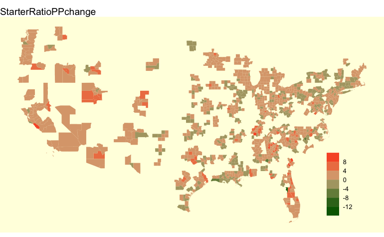

```r
#unique(summy2$X1)

example <- ggplot(data = countiesSHP10, aes(fill = StarterRatioPPchange)) +
     labs(title = "StarterRatioPPchange") +
  geom_sf(color = NA) +
  theme_void() +
  scale_fill_steps2(n.breaks = 7, low = "darkgreen", mid = "tan", high = "red", midpoint = .4) +
  theme(legend.justification = c(0, 1),
        legend.position = c(.85, .39)) +
  theme(legend.title=element_blank()) +
  theme(panel.background = element_rect(color = FALSE, fill = "lightyellow"))

example
```

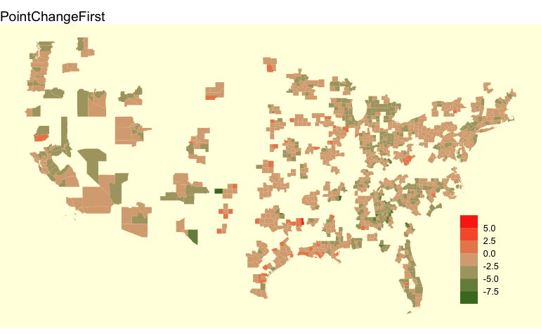

```r
example2 <- ggplot(data = countiesSHP10, aes(fill = PointChangeFirst)) +
     labs(title = "PointChangeFirst") +
  geom_sf(color = NA) +
  theme_void() +
  scale_fill_steps2(n.breaks = 7, low = "darkgreen", mid = "tan", high = "red", midpoint = -2) +
  theme(legend.justification = c(0, 1),
        legend.position = c(.85, .39)) +
  theme(legend.title=element_blank()) +
  theme(panel.background = element_rect(color = FALSE, fill = "lightyellow"))

example2
```

## LCSA EXPLORATORY MAP GENERATOR (CSAstarterRatioPPchange & CSApointChangeFirst; Correlation = -.39)

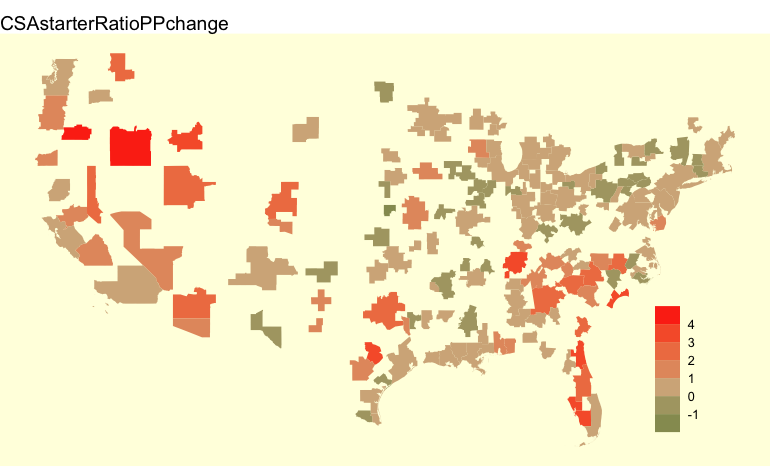

```r
#unique(summyLCSA2$X1)

example3 <- ggplot(data = LCSA_SHP10, aes(fill = CSAstarterRatioPPchange)) +
     labs(title = "CSAstarterRatioPPchange") +
  geom_sf(color = NA) +
  theme_void() +
  scale_fill_steps2(n.breaks = 10, low = "darkgreen", mid = "tan", high = "red", midpoint = .4) +
  theme(legend.justification = c(0, 1),
        legend.position = c(.85, .39)) +
  theme(legend.title=element_blank()) +
  theme(panel.background = element_rect(color = FALSE, fill = "lightyellow"))

example3
```

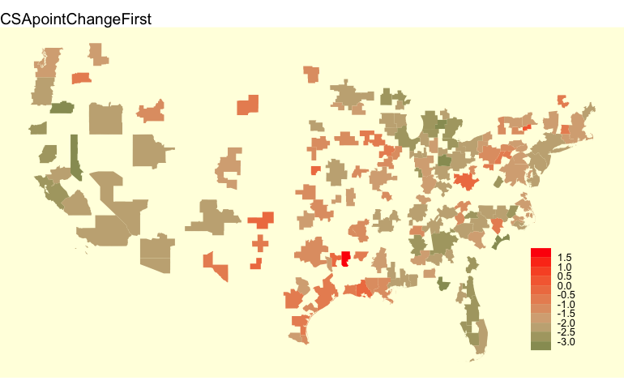

```r
example4 <- ggplot(data = LCSA_SHP10, aes(fill = CSApointChangeFirst)) +
     labs(title = "CSApointChangeFirst") +
  geom_sf(color = NA) +
  theme_void() +
  scale_fill_steps2(n.breaks = 10, low = "darkgreen", mid = "tan", high = "red", midpoint = -2) +
  theme(legend.justification = c(0, 1),
        legend.position = c(.85, .39)) +
  theme(legend.title=element_blank()) +
  theme(panel.background = element_rect(color = FALSE, fill = "lightyellow"))

example4
```

## COUNTIES EXPLORATORY MAP GENERATOR - SIMPLE EXAMPLE (pointCHANGEhispPRIMEmale & OCCroomsMOREthanONEocc_19; Correlation = .25)

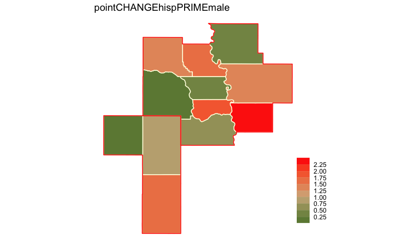

```r
example5 <- ggplot(data = Lancaster_Omaha_example, aes(fill = pointCHANGEhispPRIMEmale)) +
     labs(title = 'pointCHANGEhispPRIMEmale') +
  geom_sf(color = "lightyellow") +
  geom_sf(data = Lancaster_Omaha_LCSA_example3, fill = NA, color = "red") +
  theme_void() +
  scale_fill_steps2(n.breaks = 10, low = "darkgreen", mid = "tan", high = "red", midpoint = 1) +
  theme(legend.justification = c(0, 1),
        legend.position = c(.975, .39)) +
  theme(legend.title=element_blank()) +
  theme(panel.background = element_rect(color = FALSE, fill = NA))

example5
```

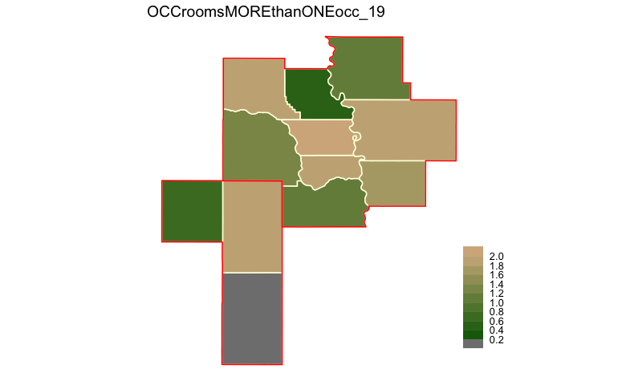

```r
example6 <- ggplot(data = Lancaster_Omaha_example, aes(fill = OCCroomsMOREthanONEocc_19)) +
     labs(title = 'OCCroomsMOREthanONEocc_19') +
  geom_sf(color = "lightyellow") +
  geom_sf(data = Lancaster_Omaha_LCSA_example3, fill = NA, color = "red") +
  theme_void() +
  scale_fill_steps2(n.breaks = 10, low = "darkgreen", mid = "tan", high = "red", midpoint = 2) +
  theme(legend.justification = c(0, 1),
        legend.position = c(.975, .39)) +
  theme(legend.title=element_blank()) +
  theme(panel.background = element_rect(color = FALSE, fill = NA))

example6
```

## LCSA EXPLORATORY MAP GENERATOR - SIMPLE EXAMPLE (csaPOINTchangeHISPprev & csaOCCrmMOREthanONE_19; Correlation = .39)

[figure not shown]

```r
example7 <- ggplot(data = Lancaster_Omaha_LCSA_example3, aes(fill = csaPOINTchangeHISPprev)) +
  labs(title = 'CSApointChangeFirst') +
  geom_sf(color = "lightyellow") +
  geom_sf(data = Lancaster_Omaha_LCSA_example3, fill = NA, color = "red") +
  theme_void() +
  scale_fill_steps2(n.breaks = 10, low = "darkgreen", mid = "tan", high = "red", midpoint = 1) +
  theme(legend.justification = c(0, 1),
        legend.position = c(.975, .39)) +
  theme(legend.title=element_blank()) +
  theme(panel.background = element_rect(color = FALSE, fill = NA))

example7
```

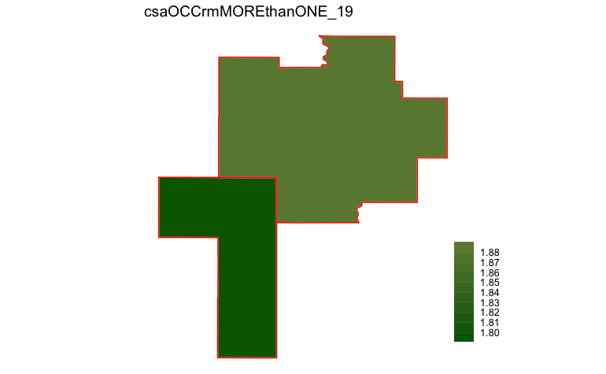

```r
example8 <- ggplot(data = Lancaster_Omaha_LCSA_example3, aes(fill = csaOCCrmMOREthanONE_19)) +
  labs(title = 'csaOCCrmMOREthanONE_19') + #percent of occupied rooms with more than one occupant in 2019
  geom_sf(color = "lightyellow") +
  geom_sf(data = Lancaster_Omaha_LCSA_example3, fill = NA, color = "red") +
  theme_void() + #midpoint in below scale_fill_steps2 set to variable median
  scale_fill_steps2(n.breaks = 10, low = "darkgreen", mid = "tan", high = "red", midpoint = 2) +
  theme(legend.justification = c(0, 1),
        legend.position = c(.975, .39)) +
  theme(legend.title=element_blank()) +
  theme(panel.background = element_rect(color = FALSE, fill = NA))

example8
```